# Sentiment Analysis on Philosophical Texts

by: Weijie Xia(wx2281)

In this project, the analysis will be based on the dataset for the philosophy data project. As time goes by, we notice a trend that the sentiment of the philosophical text tend to go from positive to neutral or even negative. This analysis aim to offer a perspective to understand this observation.

## 1. Loading The Libraries

```python
import pandas as pd
import seaborn as sns
import matplotlib.pyplot as plt
from nltk.sentiment import SentimentIntensityAnalyzer
from nltk.probability import FreqDist
from nltk.corpus import stopwords
from wordcloud import WordCloud
from gensim.models import Word2Vec
from gensim import models, corpora
import nltk
import ast

# nltk.download('punkt')
# nltk.download('stopwords')
# nltk.download('vader_lexicon')
```

## 2. Exploratory Data Analysis (EDA)

```python
# load the dataset

df = pd.read_csv('philosophy_data.csv')
```

We will first take a glance at the dataset.

```python
df.info()
```

```
<class 'pandas.core.frame.DataFrame'>
RangeIndex: 360808 entries, 0 to 360807
Data columns (total 11 columns):
 #   Column                     Non-Null Count   Dtype
---  ------                     --------------   -----
 0   title                      360808 non-null  object
 1   author                     360808 non-null  object
 2   school                     360808 non-null  object
 3   sentence_spacy             360808 non-null  object
 4   sentence_str               360808 non-null  object
 5   original_publication_date  360808 non-null  int64
 6   corpus_edition_date        360808 non-null  int64
 7   sentence_length            360808 non-null  int64
 8   sentence_lowered           360808 non-null  object
 9   tokenized_txt              360808 non-null  object
 10  lemmatized_str             360808 non-null  object
dtypes: int64(3), object(8)
memory usage: 30.3+ MB
```

```python
df.head()
```

[output not shown]

Next, we will add in sentiment score based on the philosophical texts in the dataset. This is achieved by using the SentimentIntensityAnalyzer from nltk package. The compound sentiment score will range from -1 to 1, indicating respectively from a negative attitude to a positive attitude.

```python
# sentiment analysis
sia = SentimentIntensityAnalyzer()
df['sentiment_scores'] = df['sentence_str'].apply(lambda x: sia.polarity_scores(x))
df['compound_sent_score'] = df['sentiment_scores'].apply(lambda x: x['compound'])
```

Delete unnecessary columns for this analysis and save the preprocessed dataset.

```python
df.drop(columns=['sentence_spacy','corpus_edition_date','sentiment_scores', 'lemmatized_str', 'sentence_lowered'], inplace=True)
df.to_csv("preprocessed_df.csv")
df = pd.read_csv("preprocessed_df.csv")
```

```python
df = pd.read_csv("preprocessed_df.csv")
```

### 2.1 Distribution of philosophical texts count by author

In the graph we can see that Aristotle and Plato are two of the philosopher with the most texts in the dataset.

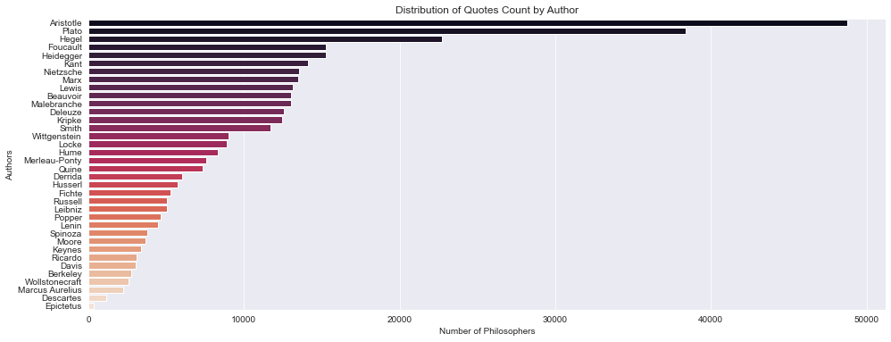

```python
# Plot the distribution of philosopher count by author

# Group the data by author and count the number of philosophers per author
plt.figure(figsize=(16,6))
philosopher_count = df.groupby('author')['author'].count().reset_index(name='counts')

# Sort the philosopher_count dataframe in descending order of count
philosopher_count = philosopher_count.sort_values(by='counts', ascending=False)

# Plot the distribution of philosopher count by author
sns.set_style("darkgrid")
sns.barplot(y='author', x='counts', data=philosopher_count, palette="rocket")
plt.ylabel('Authors')
plt.xlabel('Number of Philosophers')
plt.title('Distribution of Quotes Count by Author')
plt.show()
```

### 2.2 Distribution of philosophical texts count by school

In the graph below we can see that analytic is the school of thoughts that has the most philosophical texts, and stoicism has the least philosophical texts.

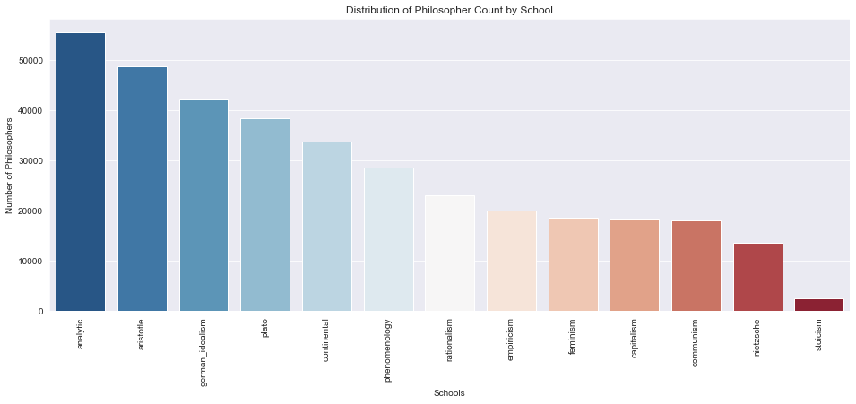

```python
# Group the data by school and count the number of philosophers per school
plt.figure(figsize=(16,6))
philosopher_count = df.groupby('school')['school'].count().reset_index(name='counts')

# Sort the philosopher_count dataframe in descending order of count
philosopher_count = philosopher_count.sort_values(by='counts', ascending=False)

# Plot the distribution of philosopher count by school
sns.set_style("darkgrid")
sns.barplot(x='school', y='counts', data=philosopher_count, palette="RdBu_r")
plt.xticks(rotation=90)
plt.xlabel('Schools')
plt.ylabel('Number of Philosophers')
plt.title('Distribution of Philosopher Count by School')
plt.show()
```

### 2.3 Distribution of sentence length

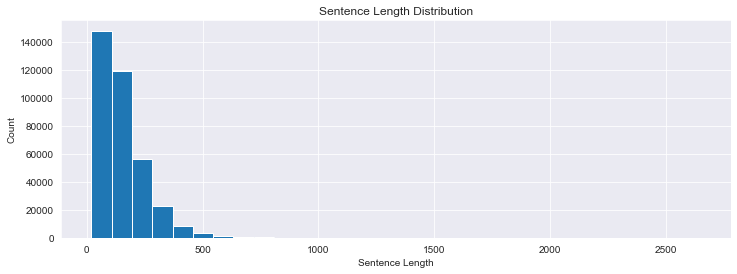

```python
# Plot the distribution of sentence length
df.sentence_length.plot(kind='hist', figsize=(12,4), title='Sentence Length Distribution', bins = 30)
plt.xlabel('Sentence Length')
plt.ylabel('Count')
plt.show()
```

### 2.4 Distribution of the sentence length across authors

Interesting fact: Descartes writes the longest texts by average.

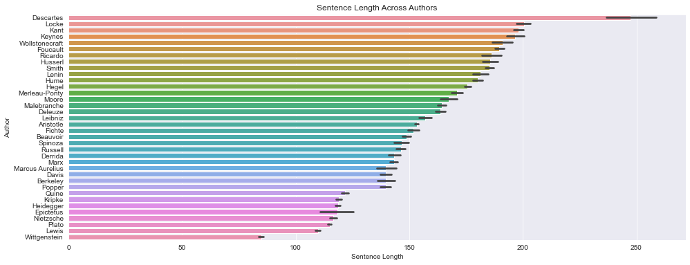

```python
# Plot the sentence length distribution across authors
plt.figure(figsize=(16,6))
sns.set_style("darkgrid")
sns.barplot(y='author', x='sentence_length', data=df, order = df.groupby(['author']).sentence_length.mean().sort_values(ascending = False).index)

plt.ylabel('Author')
plt.xlabel('Sentence Length')
plt.title('Sentence Length Across Authors')
plt.show()
```

### 2.5 Distribution of the sentence length across the school of thoughts

Capitalism has the longest philosophical texts on average, while the Plato has the shortest.

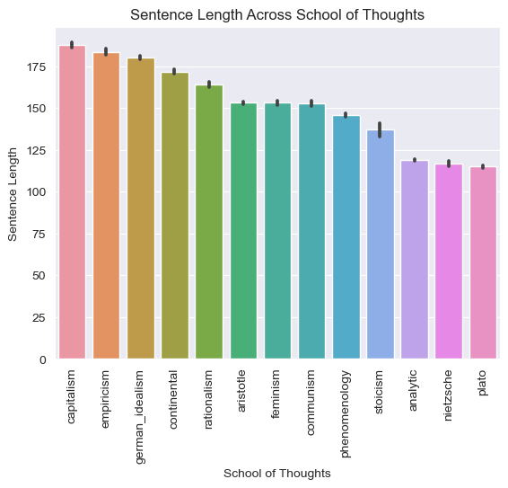

```python
# plot the sentence length across the school of thoughts
sns.set_style("darkgrid")
sns.barplot(x='school', y='sentence_length',
            data=df,
            order = df.groupby(['school']).sentence_length.mean().sort_values(ascending = False).index)

plt.xlabel('School of Thoughts')
plt.ylabel('Sentence Length')
plt.title('Sentence Length Across School of Thoughts')
plt.xticks(rotation=90)
plt.show()
```

## 3. Overall Word Frequency Analysis

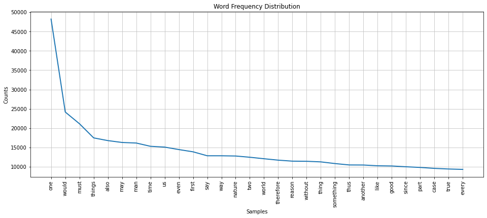

```
Number of unique words: 90187
```

```python
# text analysis


#Flatten the list of tokens into a single list
# ast.literal_eval convert a list in the form of string into a actual list
df['tokenized_txt'] = df['tokenized_txt'].apply(lambda x: ast.literal_eval(x))

all_tokens = [token for tokens in df['tokenized_txt'] for token in tokens]

# Remove stop words from the tokenized text
stop_words = set(stopwords.words("english"))
all_tokens = [token for token in all_tokens if token.lower() not in stop_words]

# Plot the word frequency distribution
fd = FreqDist(all_tokens)
plt.figure(figsize=(16,6))
fd.plot(30, cumulative=False, title='Word Frequency Distribution')


# print unique words
num_unique_words = len(set(all_tokens))
print(f"Number of unique words: {num_unique_words}")
```

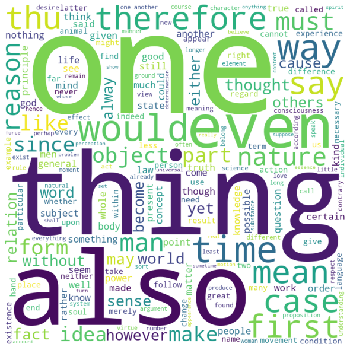

```python
# make a wordcloud

all_tokens_str = ' '.join(all_tokens)
wordcloud = WordCloud(width=800, height=800, background_color='white', stopwords=stop_words, min_font_size=10).generate(all_tokens_str)
plt.figure(figsize=(8, 8), facecolor=None)
plt.imshow(wordcloud)
plt.axis("off")
plt.tight_layout(pad=0)
plt.show()
```

## 4. Sentiment Analysis

### 4.1 Overall distribution of compound sentiment scores

First of all, we will plot the overall distribution of compound sentiment scores.

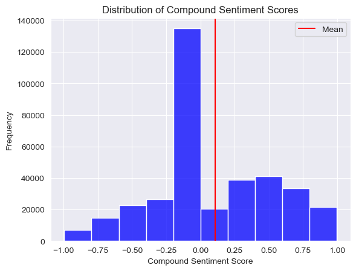

```python
# Plot the distribution of compound sentiment scores
sns.set_style("darkgrid")
sns.histplot(df['compound_sent_score'], color="blue", bins=10)

# Calculate the mean of the compound sentiment scores
mean_sentiment = df['compound_sent_score'].mean()

# Add a vertical line indicating the mean
plt.axvline(mean_sentiment, color='red', label='Mean')


plt.xlabel('Compound Sentiment Score')
plt.ylabel('Frequency')
plt.title('Distribution of Compound Sentiment Scores')
plt.legend()
plt.show()
```

### 4.2 Overall sentiment shift across time

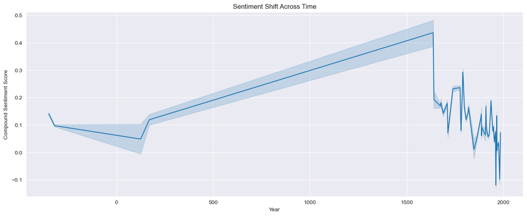

```python
# overall sentiment shift across time

# Plot the mean compound sentiment score by year
plt.figure(figsize=(16,6))

sns.lineplot(x='original_publication_date', y='compound_sent_score', data=df)

plt.xlabel('Year')
plt.ylabel('Compound Sentiment Score')
# plt.ticklabel_format(useOffset=False)
plt.title('Sentiment Shift Across Time')
plt.show()
```

### 4.3 Sentiment shift across time based on school of thoughts

In order to get a clearer view of what school of thoughts cause the change in the sentiment, we focus on the school of thoughts after 1500. we may notice that, compared to **rationalism** and **empiricism**, **feminism**(especially after 1950), **analytic** and **continental** exhibit the lowest sentiment compound scores on average among all the school of thoughts.

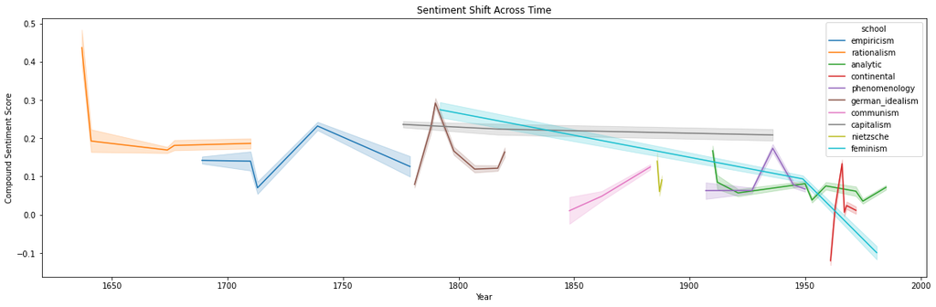

```python
# plot of sentiment shift across time based on school of thoughts
plt.figure(figsize=(16,6))
sns.lineplot(x='original_publication_date', y='compound_sent_score', hue = 'school', data=df[df['original_publication_date'] >=1500])

plt.xlabel('Year')
plt.ylabel('Compound Sentiment Score')
# plt.ticklabel_format(useOffset=False)
plt.title('Sentiment Shift Across Time')

plt.show()
```

## 5. Analysis on the Shift of the Sentiment

In this section, we want to take a close look on the five school of thoughts mentioned last section, which is **rationalism**, **empiricism**, **feminism**(especially after 1950), **analytic** and **continental**. We will perform word frequency analysis on each of the school and train Word2vec models on each of them to see different schools of thoughts react to same words. Through the analysis on texts we wish to know what cause the sentiment shift.

### 5.1 Word clouds analysis for different schools of thoughts

```python
# Filter different dataframe for different schools

df_rationalism = df[df['school'] == 'rationalism']
df_empiricism = df[df['school'] == 'empiricism']


df_analytic = df[df['school'] == 'analytic']
df_continental = df[df['school'] == 'continental']
df_feminism = df[(df['school'] == 'feminism') & (df['original_publication_date'] >= 1950)]
```

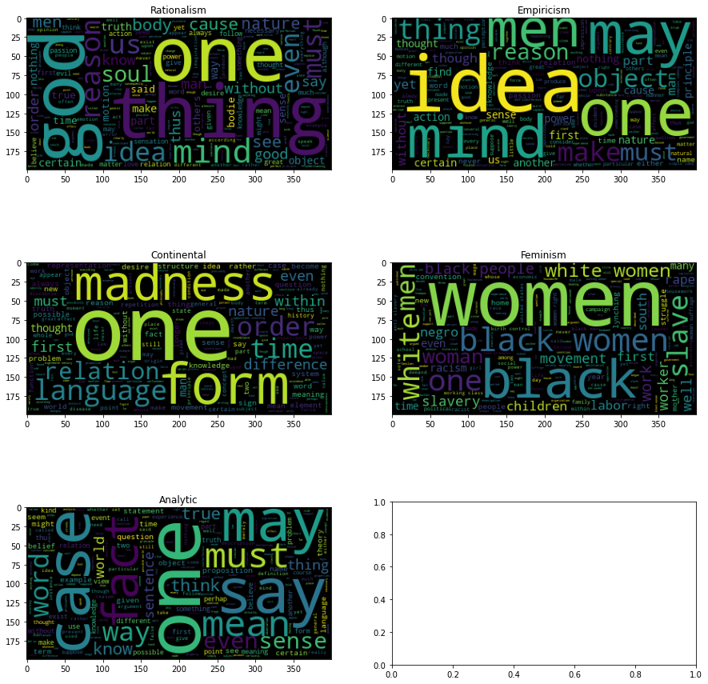

```python
# Define a function that take in the Dataframe we filtered above
# and output a string of words that can be used to generate word cloud

def get_wordcloud_text(dataframe):
    stop_words = set(stopwords.words("english"))
    tokens_list = [token for tokens in dataframe['tokenized_txt'] for token in tokens]
    # Remove stop words from the tokenized text
    tokens_list = [token for token in tokens_list if token.lower() not in stop_words]
    return ' '.join(tokens_list)

rationalism_text = get_wordcloud_text(df_rationalism)
analytic_text = get_wordcloud_text(df_analytic)
continental_text = get_wordcloud_text(df_continental)
feminism_text = get_wordcloud_text(df_feminism)
empiricism_text = get_wordcloud_text(df_empiricism)



# Create word clouds for each school
wordcloud_rationalism = WordCloud().generate(rationalism_text)
wordcloud_analytic = WordCloud().generate(analytic_text)
wordcloud_continental = WordCloud().generate(continental_text)
wordcloud_feminism = WordCloud().generate(feminism_text)
wordcloud_empiricism = WordCloud().generate(empiricism_text)

# Plot subplots
fig, axs = plt.subplots(3, 2, figsize=(15, 15))
axs[0, 0].imshow(wordcloud_rationalism, cmap='gray')
axs[0, 0].set_title('Rationalism')
axs[0, 1].imshow(wordcloud_empiricism, cmap='gray')
axs[0, 1].set_title('Empiricism')
axs[1, 0].imshow(wordcloud_continental, cmap='gray')
axs[1, 0].set_title('Continental')
axs[1, 1].imshow(wordcloud_feminism, cmap='gray')
axs[1, 1].set_title('Feminism')
axs[2, 0].imshow(wordcloud_analytic, cmap='gray')
axs[2, 0].set_title('Analytic')

# Adjust subplot spacing
plt.subplots_adjust(hspace=0.5)

# Show plot
plt.show()
```

From the word clouds of **Rationalism** and **Empiricism**, the frequent words used in the texts are positive or neutral. We can see words such as "nature", "idea", "mind", "soul" and "reason." However, after 20 centuries, the philosophers in **Analytic**, **Continental** and **Feminism** based their discussions on more radical subjects such as "slavery", "racism" , "problem", and "madness." These are powerful words that tend to result in negative sentiment. Therefore, it results in a negative shift in sentiment of the texts as time goes by.

### 5.2 Word2Vec models for different schools of thoughts

Word2vec is powerful tool from the gensim package that is for topic modelling. Word2vec model can vectorize the texts and allow us to find the most similar words.

Train the models first.

```python
# train word2vec models for different schools of thoughts

w2v_model_rationalism = Word2Vec(df_rationalism['tokenized_txt'], min_count=1)
w2v_model_empiricism = Word2Vec(df_empiricism['tokenized_txt'], min_count=1)


w2v_model_analytic = Word2Vec(df_analytic['tokenized_txt'], min_count=1)
w2v_model_feminism = Word2Vec(df_feminism['tokenized_txt'], min_count=1)
w2v_model_continental = Word2Vec(df_continental['tokenized_txt'], min_count=1)
```

```python
# save the model
# w2v_model.save("w2v_model.gensim")
# model = models.Word2Vec.load("w2v_model.gensim")
# print("Most similar words to 'philosophy': ", model.wv.most_similar('opinion'), topn = 5)
```

Next, we will feed certain words to the five models and see what is the most similar words in different schools of thoughts.

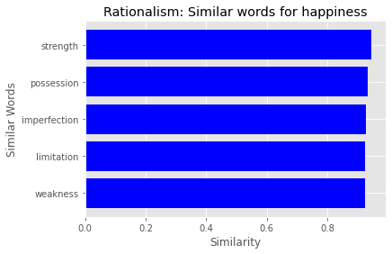

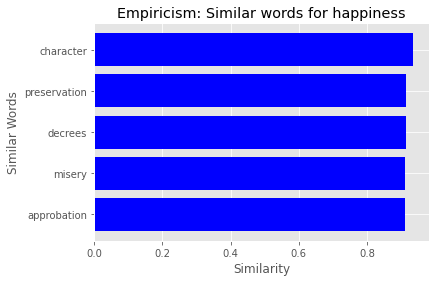

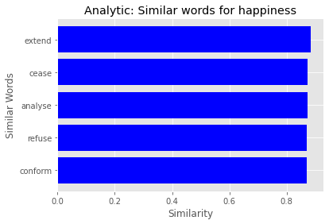

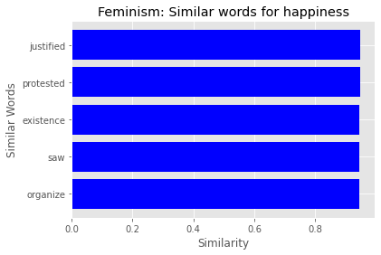

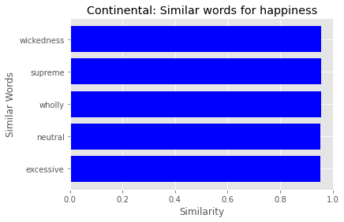

```python
# test it out

# happiness for rationalism
sims = w2v_model_rationalism.wv.most_similar('happiness', topn=5)

sim_word = []
sim_str  = []
for i in range(len(sims)):
    sim_word.append(sims[i][0])
for i in range(len(sims)):
    sim_str.append(sims[i][1])
sim_word = list(reversed(sim_word))
sim_str  = list(reversed(sim_str))


y = sim_word
x = sim_str
plt.style.use('ggplot')
plt.barh(y,x,color=['blue'])
plt.title('Rationalism: Similar words for happiness')
plt.ylabel('Similar Words')
plt.xlabel('Similarity')

plt.show()

# happiness for empiricism
sims = w2v_model_empiricism.wv.most_similar('happiness', topn=5)

sim_word = []
sim_str  = []
for i in range(len(sims)):
    sim_word.append(sims[i][0])
for i in range(len(sims)):
    sim_str.append(sims[i][1])
sim_word = list(reversed(sim_word))
sim_str  = list(reversed(sim_str))


y = sim_word
x = sim_str
plt.style.use('ggplot')
plt.barh(y,x,color=['blue'])
plt.title('Empiricism: Similar words for happiness')
plt.ylabel('Similar Words')
plt.xlabel('Similarity')


plt.show()

# happiness for analytic
sims = w2v_model_analytic.wv.most_similar('happiness', topn=5)

sim_word = []
sim_str  = []
for i in range(len(sims)):
    sim_word.append(sims[i][0])
for i in range(len(sims)):
    sim_str.append(sims[i][1])
sim_word = list(reversed(sim_word))
sim_str  = list(reversed(sim_str))


y = sim_word
x = sim_str
plt.style.use('ggplot')
plt.barh(y,x,color=['blue'])
plt.title('Analytic: Similar words for happiness')
plt.ylabel('Similar Words')
plt.xlabel('Similarity')


plt.show()


# happiness for feminism
sims = w2v_model_feminism.wv.most_similar('happiness', topn=5)

sim_word = []
sim_str  = []
for i in range(len(sims)):
    sim_word.append(sims[i][0])
for i in range(len(sims)):
    sim_str.append(sims[i][1])
sim_word = list(reversed(sim_word))
sim_str  = list(reversed(sim_str))


y = sim_word
x = sim_str
plt.style.use('ggplot')
plt.barh(y,x,color=['blue'])
plt.title('Feminism: Similar words for happiness')
plt.ylabel('Similar Words')
plt.xlabel('Similarity')


plt.show()

# happiness for continental
sims = w2v_model_continental.wv.most_similar('happiness', topn=5)

sim_word = []
sim_str  = []
for i in range(len(sims)):
    sim_word.append(sims[i][0])
for i in range(len(sims)):
    sim_str.append(sims[i][1])
sim_word = list(reversed(sim_word))
sim_str  = list(reversed(sim_str))


y = sim_word
x = sim_str
plt.style.use('ggplot')
plt.barh(y,x,color=['blue'])
plt.title('Continental: Similar words for happiness')
plt.ylabel('Similar Words')
plt.xlabel('Similarity')


plt.show()
```

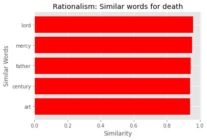

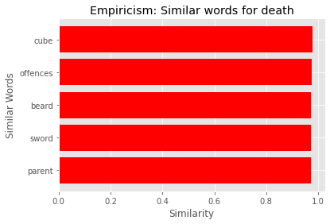

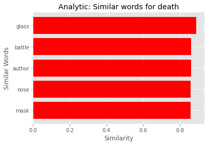

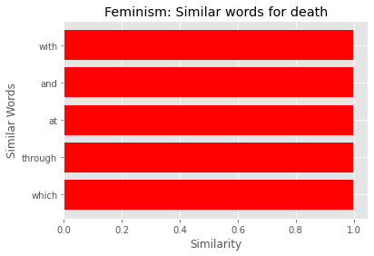

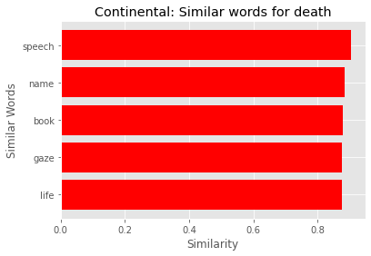

```python
# death for rationalism
sims = w2v_model_rationalism.wv.most_similar('death', topn=5)

sim_word = []
sim_str  = []
for i in range(len(sims)):
    sim_word.append(sims[i][0])
for i in range(len(sims)):
    sim_str.append(sims[i][1])
sim_word = list(reversed(sim_word))
sim_str  = list(reversed(sim_str))


y = sim_word
x = sim_str
plt.style.use('ggplot')
plt.barh(y,x,color=['red'])
plt.title('Rationalism: Similar words for death')
plt.ylabel('Similar Words')
plt.xlabel('Similarity')

plt.show()

# death for empiricism
sims = w2v_model_empiricism.wv.most_similar('death', topn=5)

sim_word = []
sim_str  = []
for i in range(len(sims)):
    sim_word.append(sims[i][0])
for i in range(len(sims)):
    sim_str.append(sims[i][1])
sim_word = list(reversed(sim_word))
sim_str  = list(reversed(sim_str))


y = sim_word
x = sim_str
plt.style.use('ggplot')
plt.barh(y,x,color=['red'])
plt.title('Empiricism: Similar words for death')
plt.ylabel('Similar Words')
plt.xlabel('Similarity')


plt.show()

# death for analytic
sims = w2v_model_analytic.wv.most_similar('death', topn=5)

sim_word = []
sim_str  = []
for i in range(len(sims)):
    sim_word.append(sims[i][0])
for i in range(len(sims)):
    sim_str.append(sims[i][1])
sim_word = list(reversed(sim_word))
sim_str  = list(reversed(sim_str))


y = sim_word
x = sim_str
plt.style.use('ggplot')
plt.barh(y,x,color=['red'])
plt.title('Analytic: Similar words for death')
plt.ylabel('Similar Words')
plt.xlabel('Similarity')


plt.show()


# death for feminism
sims = w2v_model_feminism.wv.most_similar('death', topn=5)

sim_word = []
sim_str  = []
for i in range(len(sims)):
    sim_word.append(sims[i][0])
for i in range(len(sims)):
    sim_str.append(sims[i][1])
sim_word = list(reversed(sim_word))
sim_str  = list(reversed(sim_str))


y = sim_word
x = sim_str
plt.style.use('ggplot')
plt.barh(y,x,color=['red'])
plt.title('Feminism: Similar words for death')
plt.ylabel('Similar Words')
plt.xlabel('Similarity')


plt.show()

# death for continental
sims = w2v_model_continental.wv.most_similar('death', topn=5)

sim_word = []
sim_str  = []
for i in range(len(sims)):
    sim_word.append(sims[i][0])
for i in range(len(sims)):
    sim_str.append(sims[i][1])
sim_word = list(reversed(sim_word))
sim_str  = list(reversed(sim_str))


y = sim_word
x = sim_str
plt.style.use('ggplot')
plt.barh(y,x,color=['red'])
plt.title('Continental: Similar words for death')
plt.ylabel('Similar Words')
plt.xlabel('Similarity')


plt.show()
```

From the above graphs, when we feed positive word "happiness" to continental, we see wickedness is the most similar words to it. When we feed the negative word "death" to rationalism, we see the most similar words could be "father" and "mercy", words that are less negative. In some way, this also supports our claim that as time goes by, the philosophical texts has a shift in sentiment.